# Kvantni generator random števil

Ta Jupyter zvezek implementira kvantni generator random števil z uporabo Qiskita.

## Predpogoji

- Namestite potrebne pakete: qiskit, qiskit-aer, numpy, matplotlib

**Opombe**:

- Zadnje tri števke študentske številke: 737 (Nemanja Mitric).
- Poljubno število: 360.
- Število poskusov: 1.000.000.

## Pripomočkovne funkcije

```python
from qiskit import QuantumCircuit, QuantumRegister, ClassicalRegister
from qiskit_aer import AerSimulator
import matplotlib.pyplot as plt
import numpy as np

def simulateCircuit(quantumCircuit, numShots=1000000):
    simulator = AerSimulator()
    job = simulator.run(quantumCircuit, shots=numShots)
    result = job.result()
    counts = result.get_counts()

    numbers = np.array([int(key, 2) for key in counts.keys()])
    frequencies = np.array([counts[key] for key in counts.keys()])
    probabilities = frequencies / numShots

    return numbers, probabilities

def plotDistribution(numbers, probabilities, title, targetNumbers=None, targetProbabilities=None):
    plt.figure(figsize=(10, 5))
    plt.bar(numbers, probabilities, width=1.0)

    if targetNumbers and targetProbabilities:
        colors = ['r', 'g']
        for idx, (num, prob) in enumerate(zip(targetNumbers, targetProbabilities)):
            plt.axvline(x=num, color=colors[idx], linestyle='--', label=f'Target {num} (p={prob})')
            plt.axhline(y=prob, color=colors[idx], linestyle=':', alpha=0.5, label=f'p={prob}')
    else:
        plt.axhline(y=1/256, color='r', linestyle='--', label='Ideal (1/256)')

    plt.xlabel('Number')
    plt.ylabel('Probability')
    plt.title(title)
    plt.legend()
    plt.show()

def plotDistributionWithThickerBar(numbers, probabilities, title, targetNumbers=None, targetProbabilities=None):
    plt.figure(figsize=(12, 5))
    widths = np.array([10.0 if prob > 0.1 else 0.5 for prob in probabilities])

    for i, (num, prob, width) in enumerate(zip(numbers, probabilities, widths)):
        plt.bar(num, prob, width=width, align='center')

    if targetNumbers and targetProbabilities:
        colors = ['r', 'g']
        for idx, (num, prob) in enumerate(zip(targetNumbers, targetProbabilities)):
            plt.axvline(x=num, color=colors[idx], linestyle='--', label=f'Target {num} (p={prob})')
            plt.axhline(y=prob, color=colors[idx], linestyle=':', alpha=0.5, label=f'p={prob}')
    else:
        plt.axhline(y=1/256, color='r', linestyle='--', label='Ideal (1/256)')

    plt.xlabel('Number')
    plt.ylabel('Probability')
    plt.title(title)
    plt.legend()
    plt.show()
```

## Part 1: Enakomerni generatorji

### Hadamardovih vrat

- 8 kubitov, števila od 0 do 255, verjetnost 1/256 ≈ 0,00390625.
- Hadamardova vrata: H = 1/√2 [[1, 1], [1, -1]].
- Meritev: Kolapsira v 0 ali 1.

```
Hadamard Generator Probabilities:
Number 46: Probability 0.004007
Number 156: Probability 0.003979
Number 214: Probability 0.003888
Number 243: Probability 0.003801
Number 198: Probability 0.003918
Number 175: Probability 0.003878
Number 228: Probability 0.003919
Number 111: Probability 0.003929
Number 193: Probability 0.003958
Number 169: Probability 0.003808
```

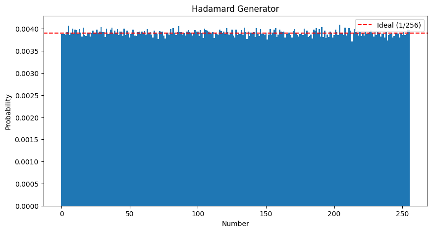

```python
def createHadamardGenerator(numQubits=8):
    qubitRegister = QuantumRegister(numQubits, 'q')
    classicalRegister = ClassicalRegister(numQubits, 'c')
    quantumCircuit = QuantumCircuit(qubitRegister, classicalRegister)

    for qubitIndex in range(numQubits):
        quantumCircuit.h(qubitIndex)

    quantumCircuit.measure(qubitRegister, classicalRegister)
    return quantumCircuit

numQubits = 8
hadamardCircuit = createHadamardGenerator(numQubits)
numbers, probabilities = simulateCircuit(hadamardCircuit)

print("Hadamard Generator Probabilities:")
for num, prob in zip(numbers[0:10], probabilities[0:10]):
    print(f"Number {num}: Probability {prob:.6f}")

plotDistribution(numbers, probabilities, 'Hadamard Generator')
```

### Na osnovi rotacij

- Enako kot zgoraj, z uporabo Ry(π/2).
- Ry(θ) = [[cos(θ/2), -sin(θ/2)], [sin(θ/2), cos(θ/2)]], θ = π/2.

```
Rotation Generator Probabilities:
Number 75: Probability 0.003950
Number 231: Probability 0.003939
Number 214: Probability 0.003877
Number 237: Probability 0.004018
Number 215: Probability 0.004033
Number 39: Probability 0.003992
Number 117: Probability 0.003844
Number 236: Probability 0.003919
Number 83: Probability 0.003951
Number 68: Probability 0.003984
```

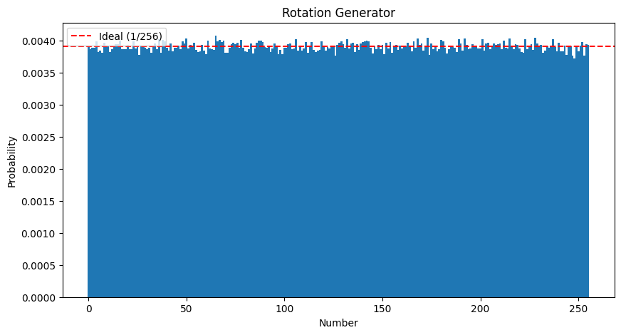

```python
def createRotationGenerator(numQubits=8):
    qubitRegister = QuantumRegister(numQubits, 'q')
    classicalRegister = ClassicalRegister(numQubits, 'c')
    quantumCircuit = QuantumCircuit(qubitRegister, classicalRegister)

    theta = np.pi / 2
    for qubitIndex in range(numQubits):
        quantumCircuit.ry(theta, qubitIndex)

    quantumCircuit.measure(qubitRegister, classicalRegister)
    return quantumCircuit

numQubits = 8
rotationCircuit = createRotationGenerator(numQubits)
numbers, probabilities = simulateCircuit(rotationCircuit)

print("Rotation Generator Probabilities:")
for num, prob in zip(numbers[0:10], probabilities[0:10]):
    print(f"Number {num}: Probability {prob:.6f}")

plotDistribution(numbers, probabilities, 'Rotation Generator')
```

## Part 2: Pristranski rotacijski generator

- 10 kubitov, generiraj 737 z verjetnostmi p = 0.25, 0.50, 0.75.
- Druga števila: (1-p)/1023.

```
Biased Generator (p=0.25 for 737):
Expected probability for non-target numbers: 0.000733138
Probability 0.000720 for Number 624
Probability 0.000729 for Number 383
Probability 0.000713 for Number 76
Probability 0.000720 for Number 16
Probability 0.000733 for Number 267
Probability 0.000745 for Number 771
Probability 0.000693 for Number 692
Probability 0.000738 for Number 625
Probability 0.000728 for Number 425
Probability 0.000730 for Number 138
```

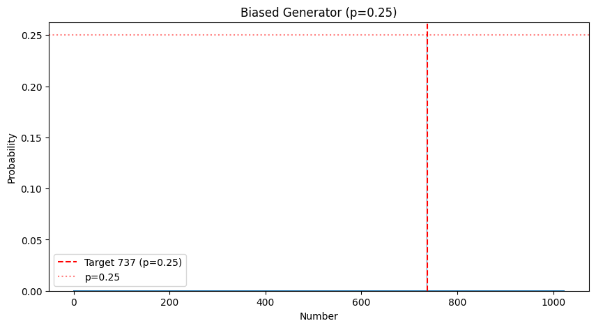

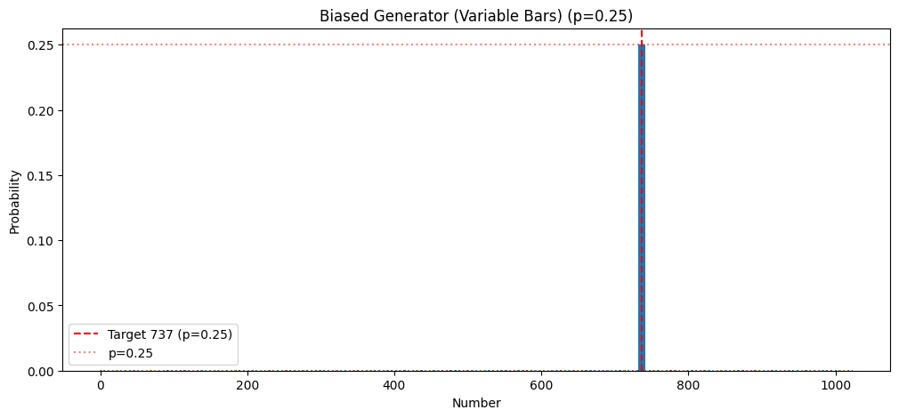

```
Biased Generator (p=0.5 for 737):
Expected probability for non-target numbers: 0.000488759
Probability 0.000442 for Number 879
Probability 0.000474 for Number 603
Probability 0.000480 for Number 254
Probability 0.000508 for Number 318
Probability 0.000493 for Number 853
Probability 0.000451 for Number 803
Probability 0.000506 for Number 719
Probability 0.000468 for Number 320
Probability 0.000508 for Number 696
Probability 0.000472 for Number 143
```

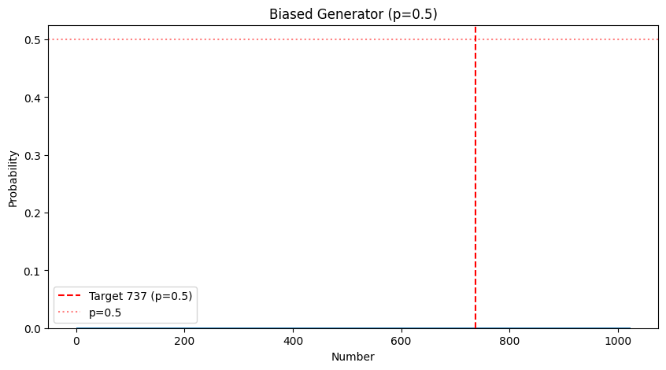

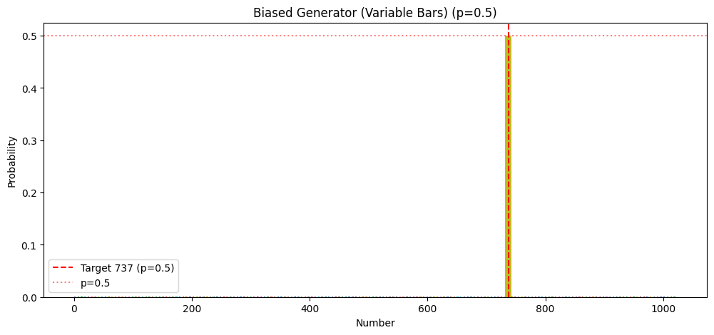

```
Biased Generator (p=0.75 for 737):
Expected probability for non-target numbers: 0.000244379
Probability 0.000219 for Number 466
Probability 0.000270 for Number 929
Probability 0.000268 for Number 553
Probability 0.000260 for Number 677
Probability 0.000244 for Number 684
Probability 0.000243 for Number 948
Probability 0.000233 for Number 79
Probability 0.000253 for Number 70
Probability 0.000251 for Number 892
Probability 0.000232 for Number 648
```

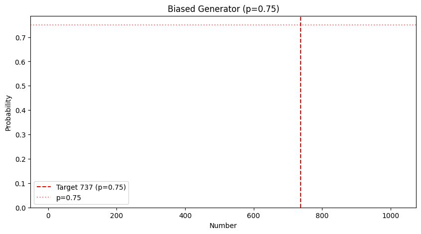

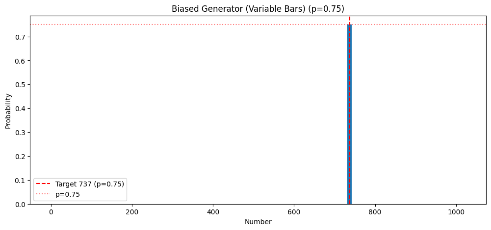

```python
def createBiasedGenerator(targetNumber=737, targetProbability=0.5, numQubits=10):
    qubitRegister = QuantumRegister(numQubits, 'q')
    classicalRegister = ClassicalRegister(numQubits, 'c')
    quantumCircuit = QuantumCircuit(qubitRegister, classicalRegister)

    numStates = 2 ** numQubits
    stateVector = np.zeros(numStates, dtype=complex)

    stateVector[targetNumber] = np.sqrt(targetProbability)
    remainingProbability = 1 - targetProbability
    numOtherStates = numStates - 1
    amplitudeOther = np.sqrt(remainingProbability / numOtherStates) if numOtherStates > 0 else 0

    for i in range(numStates):
        if i != targetNumber:
            stateVector[i] = amplitudeOther

    quantumCircuit.initialize(stateVector, qubitRegister)
    quantumCircuit.measure(qubitRegister, classicalRegister)

    return quantumCircuit

targetNumber = 737
probabilitiesToTest = [0.25, 0.50, 0.75]
numQubits = 10

for targetProbability in probabilitiesToTest:
    biasedCircuit = createBiasedGenerator(targetNumber, targetProbability, numQubits)
    numbers, probabilities = simulateCircuit(biasedCircuit)

    nonTargetProbability = (1 - targetProbability) / (2**numQubits - 1)
    print(f"\nBiased Generator (p={targetProbability} for {targetNumber}):")
    print(f"Expected probability for non-target numbers: {nonTargetProbability:.9f}")

    for num, prob in zip(numbers[0:10], probabilities[0:10]):
        print(f"Probability {prob:.6f} for Number {num}")

    plotDistribution(numbers, probabilities, f'Biased Generator (p={targetProbability})',
                     targetNumbers=[targetNumber], targetProbabilities=[targetProbability])
    plotDistributionWithThickerBar(numbers, probabilities, f'Biased Generator (Variable Bars) (p={targetProbability})',
                                    targetNumbers=[targetNumber], targetProbabilities=[targetProbability])
```

### Part 2 Vprašanja

1. **Kaj ste morali spremeniti v algoritmu, da ste dosegli poljubno verjetnost generiranja naključnih števil?**
   - Nastavi amplitudo √p za |737⟩, √((1-p)/1023) za ostale z uporabo "initialize" (ki uporablja rotacijske vrate).
2. **Ali bi lahko zgoraj navedene poljubne verjetnosti (0,25, 0,50 in 0,75), dosegli s pomočjo Hadamardovih vrat?**
   - Ne. Hadamardova vrata dajejo enake verjetnosti (1/1024 za 10 kubitov). Rotacijska vrata prilagajajo amplitude za neenake verjetnosti.
3. **S kakšno verjetnostjo se v vašem generatorju generirajo ostala števila (poleg tistega, ki ga določajo zadnje tri cifre vaše vpisne številke)?**
   - p = 0.25: 0.75/1023 ≈ 0.000733
   - p = 0.50: 0.50/1023 ≈ 0.000489
   - p = 0.75: 0.25/1023 ≈ 0.000244

```
Biased Generator (p=0.25 for 737):
Expected probability for non-target numbers: 0.000733138
Probability 0.000721 for Number 590
Probability 0.000726 for Number 554
Probability 0.000714 for Number 143
Probability 0.000716 for Number 229
Probability 0.000712 for Number 58
Probability 0.000739 for Number 158
Probability 0.000749 for Number 578
Probability 0.000733 for Number 510
Probability 0.000752 for Number 886
Probability 0.000753 for Number 819
```

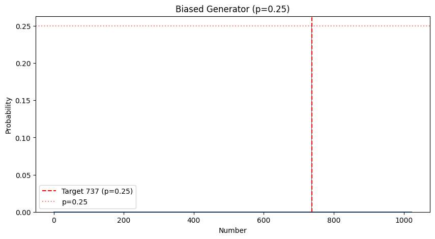

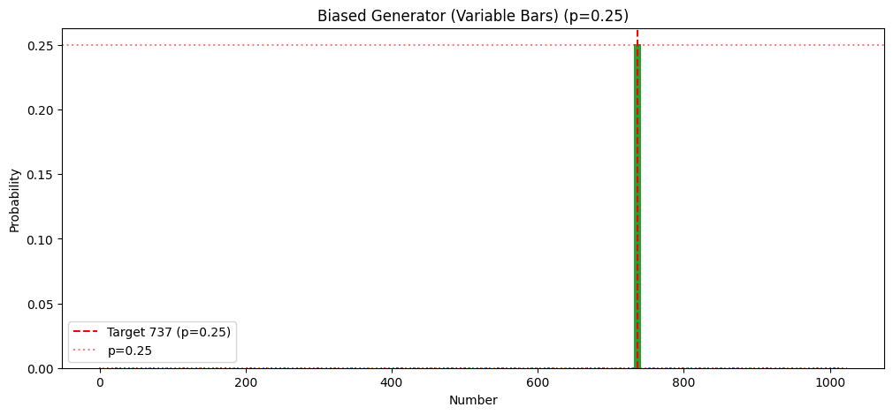

```
Biased Generator (p=0.5 for 737):
Expected probability for non-target numbers: 0.000488759
Probability 0.000454 for Number 598
Probability 0.000473 for Number 359
Probability 0.000517 for Number 608
Probability 0.000446 for Number 771
Probability 0.000519 for Number 740
Probability 0.000503 for Number 687
Probability 0.000498 for Number 435
Probability 0.000487 for Number 348
Probability 0.000476 for Number 568
Probability 0.000460 for Number 618
```

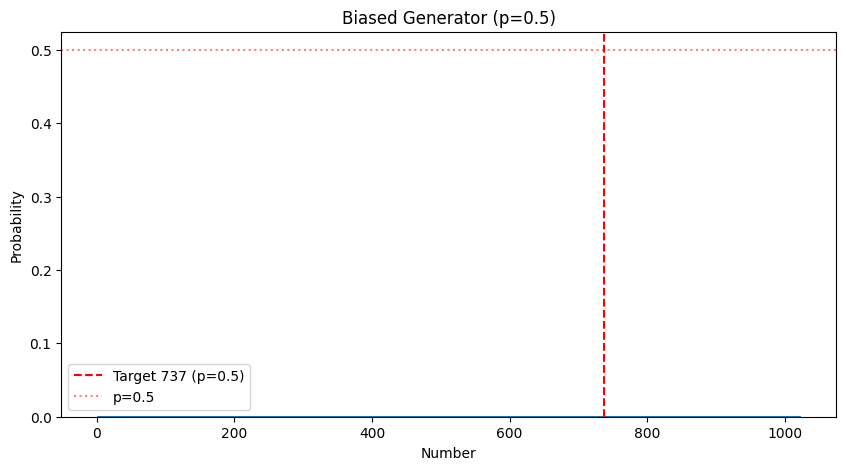

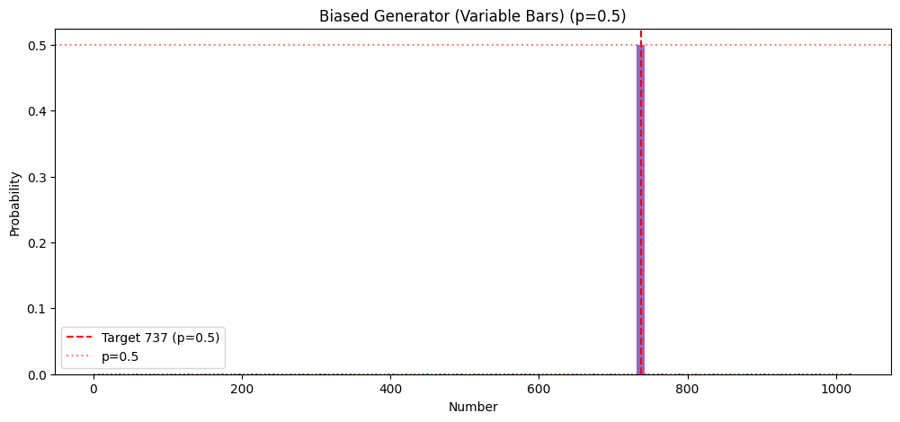

```
Biased Generator (p=0.75 for 737):
Expected probability for non-target numbers: 0.000244379
Probability 0.000243 for Number 365
Probability 0.000239 for Number 359
Probability 0.000222 for Number 4
Probability 0.000235 for Number 777
Probability 0.000230 for Number 1017
Probability 0.000222 for Number 553
Probability 0.000249 for Number 714
Probability 0.000268 for Number 853
Probability 0.000232 for Number 698
Probability 0.000247 for Number 312
```

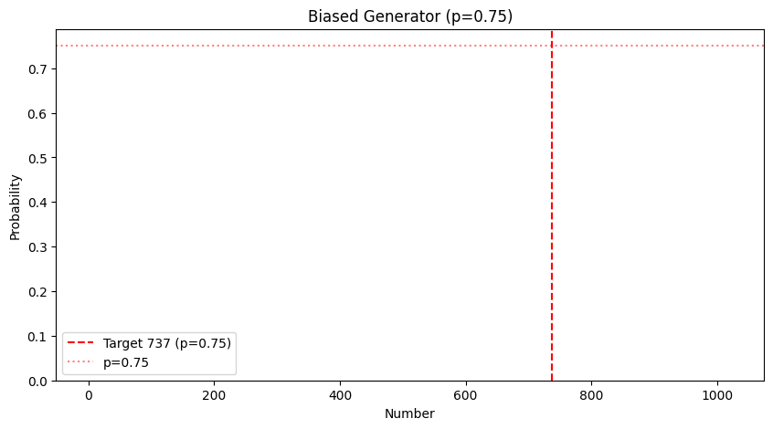

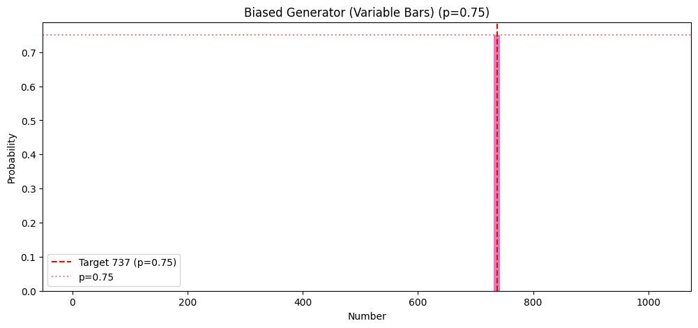

```python
def createBiasedGenerator(targetNumber=737, targetProbability=0.5, numQubits=10):
    qubitRegister = QuantumRegister(numQubits, 'q')
    classicalRegister = ClassicalRegister(numQubits, 'c')
    quantumCircuit = QuantumCircuit(qubitRegister, classicalRegister)

    numStates = 2 ** numQubits
    stateVector = np.zeros(numStates, dtype=complex)

    stateVector[targetNumber] = np.sqrt(targetProbability)
    remainingProbability = 1 - targetProbability
    numOtherStates = numStates - 1
    amplitudeOther = np.sqrt(remainingProbability / numOtherStates) if numOtherStates > 0 else 0

    for i in range(numStates):
        if i != targetNumber:
            stateVector[i] = amplitudeOther

    quantumCircuit.initialize(stateVector, qubitRegister)
    quantumCircuit.measure(qubitRegister, classicalRegister)

    return quantumCircuit

targetNumber = 737
probabilitiesToTest = [0.25, 0.50, 0.75]
numQubits = 10

for targetProbability in probabilitiesToTest:
    biasedCircuit = createBiasedGenerator(targetNumber, targetProbability, numQubits)
    numbers, probabilities = simulateCircuit(biasedCircuit)

    nonTargetProbability = (1 - targetProbability) / (2**numQubits - 1)
    print(f"\nBiased Generator (p={targetProbability} for {targetNumber}):")
    print(f"Expected probability for non-target numbers: {nonTargetProbability:.9f}")

    for num, prob in zip(numbers[0:10], probabilities[0:10]):
        print(f"Probability {prob:.6f} for Number {num}")

    plotDistribution(numbers, probabilities, f'Biased Generator (p={targetProbability})',
                     targetNumbers=[targetNumber], targetProbabilities=[targetProbability])
    plotDistributionWithThickerBar(numbers, probabilities, f'Biased Generator (Variable Bars) (p={targetProbability})',
                                    targetNumbers=[targetNumber], targetProbabilities=[targetProbability])
```

## Part 3: Generator na osnovi stanjskega vektorja

- 10 kubitov, 737 (60 %), 360 (30 %), ostali 10 % / 1022.

```
Statevector Generator (p=0.6 for 737, p=0.3 for 360):
Probability 0.000096 for number 1005
Probability 0.000089 for number 803
Probability 0.000103 for number 455
Probability 0.000090 for number 1017
Probability 0.000095 for number 140
Probability 0.000093 for number 450
Probability 0.000104 for number 879
Probability 0.000109 for number 621
Probability 0.000091 for number 146
Probability 0.000107 for number 834
```

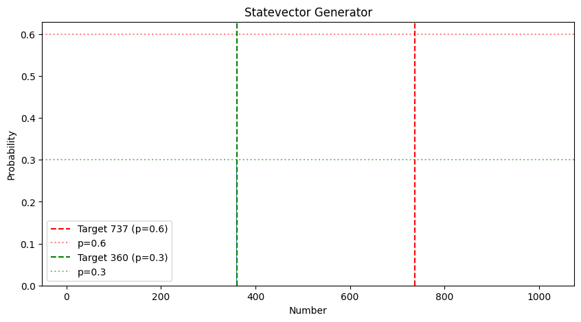

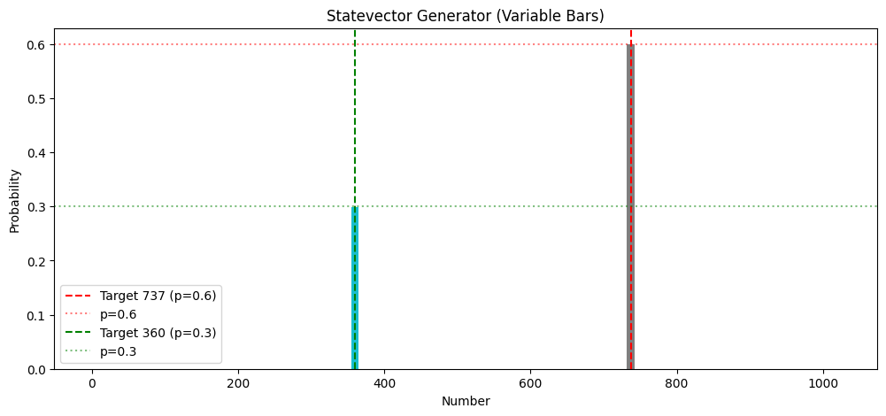

```python
def createStatevectorGenerator(firstNumber=737, firstProbability=0.6,
                              secondNumber=360, secondProbability=0.3, numQubits=10):
    qubitRegister = QuantumRegister(numQubits, 'q')
    classicalRegister = ClassicalRegister(numQubits, 'c')
    quantumCircuit = QuantumCircuit(qubitRegister, classicalRegister)

    numStates = 2 ** numQubits
    stateVector = np.zeros(numStates, dtype=complex)

    stateVector[firstNumber] = np.sqrt(firstProbability)
    stateVector[secondNumber] = np.sqrt(secondProbability)
    remainingProbability = 1 - firstProbability - secondProbability
    numOtherStates = numStates - 2
    amplitudeOther = np.sqrt(remainingProbability / numOtherStates) if numOtherStates > 0 else 0

    for i in range(numStates):
        if i not in [firstNumber, secondNumber]:
            stateVector[i] = amplitudeOther

    quantumCircuit.initialize(stateVector, qubitRegister)
    quantumCircuit.measure(qubitRegister, classicalRegister)

    return quantumCircuit

firstNumber = 737
firstProbability = 0.6
secondNumber = 360
secondProbability = 0.3
numQubits = 10

statevectorCircuit = createStatevectorGenerator(firstNumber, firstProbability,
                                               secondNumber, secondProbability, numQubits)
numbers, probabilities = simulateCircuit(statevectorCircuit)

print(f"\nStatevector Generator (p={firstProbability} for {firstNumber}, p={secondProbability} for {secondNumber}):")
for num, prob in zip(numbers[0:10], probabilities[0:10]):
    print(f"Probability {prob:.6f} for number {num}")

plotDistribution(numbers, probabilities, 'Statevector Generator',
                 targetNumbers=[firstNumber, secondNumber],
                 targetProbabilities=[firstProbability, secondProbability])
plotDistributionWithThickerBar(numbers, probabilities, 'Statevector Generator (Variable Bars)',
                                 targetNumbers=[firstNumber, secondNumber],
                                 targetProbabilities=[firstProbability, secondProbability])
```

## Part 2 (8 qb): Pristranski rotacijski generator

- 8 kubitov, generiraj 37 z verjetnostmi p = 0.25, 0.50, 0.75.
- Druga števila: (1-p)/255.

```
Biased Generator (p=0.25 for 37):
Expected probability for non-target numbers: 0.002941176
Probability 0.002968 for Number 166
Probability 0.003000 for Number 145
Probability 0.002928 for Number 84
Probability 0.002984 for Number 4
Probability 0.002965 for Number 175
Probability 0.002873 for Number 124
Probability 0.003052 for Number 243
Probability 0.002910 for Number 42
Probability 0.002945 for Number 94
Probability 0.002817 for Number 56
```

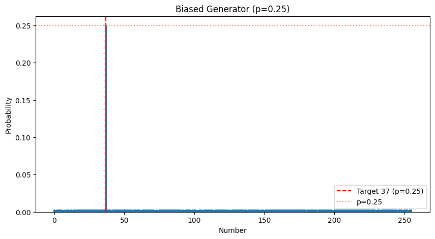

```
Biased Generator (p=0.5 for 37):
Expected probability for non-target numbers: 0.001960784
Probability 0.001957 for Number 250
Probability 0.001960 for Number 186
Probability 0.001925 for Number 148
Probability 0.001916 for Number 79
Probability 0.001896 for Number 94
Probability 0.001958 for Number 84
Probability 0.001952 for Number 20
Probability 0.001916 for Number 123
Probability 0.001997 for Number 198
Probability 0.001954 for Number 151
```

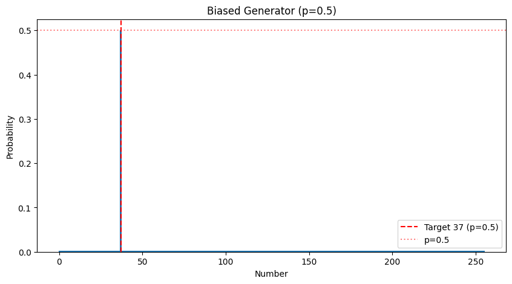

```
Biased Generator (p=0.75 for 37):
Expected probability for non-target numbers: 0.000980392
Probability 0.000938 for Number 172
Probability 0.000954 for Number 169
Probability 0.001004 for Number 81
Probability 0.000995 for Number 94
Probability 0.000928 for Number 233
Probability 0.001026 for Number 217
Probability 0.000969 for Number 79
Probability 0.000936 for Number 195
Probability 0.000975 for Number 91
Probability 0.000965 for Number 10
```

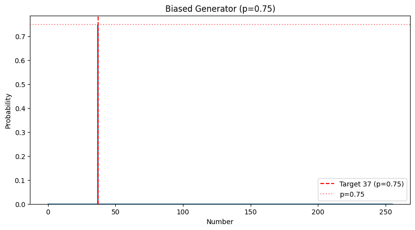

```python
def createBiasedGenerator(targetNumber=37, targetProbability=0.5, numQubits=8):
    qubitRegister = QuantumRegister(numQubits, 'q')
    classicalRegister = ClassicalRegister(numQubits, 'c')
    quantumCircuit = QuantumCircuit(qubitRegister, classicalRegister)

    numStates = 2 ** numQubits
    stateVector = np.zeros(numStates, dtype=complex)

    stateVector[targetNumber] = np.sqrt(targetProbability)
    remainingProbability = 1 - targetProbability
    numOtherStates = numStates - 1
    amplitudeOther = np.sqrt(remainingProbability / numOtherStates) if numOtherStates > 0 else 0

    for i in range(numStates):
        if i != targetNumber:
            stateVector[i] = amplitudeOther

    quantumCircuit.initialize(stateVector, qubitRegister)
    quantumCircuit.measure(qubitRegister, classicalRegister)

    return quantumCircuit

targetNumber = 37
probabilitiesToTest = [0.25, 0.50, 0.75]
numQubits = 8

for targetProbability in probabilitiesToTest:
    biasedCircuit = createBiasedGenerator(targetNumber, targetProbability, numQubits)
    numbers, probabilities = simulateCircuit(biasedCircuit)

    nonTargetProbability = (1 - targetProbability) / (2**numQubits - 1)
    print(f"\nBiased Generator (p={targetProbability} for {targetNumber}):")
    print(f"Expected probability for non-target numbers: {nonTargetProbability:.9f}")

    for num, prob in zip(numbers[0:10], probabilities[0:10]):
        print(f"Probability {prob:.6f} for Number {num}")

    plotDistribution(numbers, probabilities, f'Biased Generator (p={targetProbability})',
                     targetNumbers=[targetNumber], targetProbabilities=[targetProbability])
```

## Part 3 (8qb): Generator na osnovi stanjskega vektorja

- 8 kubitov, 37 (60 %), 60 (30 %), ostali 10 % / 254.

```
Statevector Generator (p=0.6 for 37, p=0.3 for 60):
Probability 0.000396 for number 221
Probability 0.000399 for number 39
Probability 0.000389 for number 28
Probability 0.000375 for number 4
Probability 0.000398 for number 18
Probability 0.000388 for number 176
Probability 0.000357 for number 43
Probability 0.000422 for number 66
Probability 0.000390 for number 139
Probability 0.000397 for number 10
```

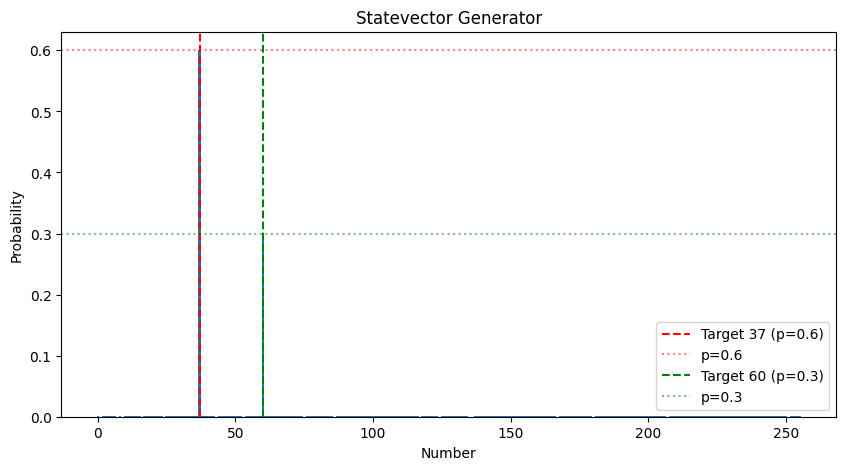

```python
def createStatevectorGenerator(firstNumber=37, firstProbability=0.6,
                              secondNumber=60, secondProbability=0.3, numQubits=8):
    qubitRegister = QuantumRegister(numQubits, 'q')
    classicalRegister = ClassicalRegister(numQubits, 'c')
    quantumCircuit = QuantumCircuit(qubitRegister, classicalRegister)

    numStates = 2 ** numQubits
    stateVector = np.zeros(numStates, dtype=complex)

    stateVector[firstNumber] = np.sqrt(firstProbability)
    stateVector[secondNumber] = np.sqrt(secondProbability)
    remainingProbability = 1 - firstProbability - secondProbability
    numOtherStates = numStates - 2
    amplitudeOther = np.sqrt(remainingProbability / numOtherStates) if numOtherStates > 0 else 0

    for i in range(numStates):
        if i not in [firstNumber, secondNumber]:
            stateVector[i] = amplitudeOther

    quantumCircuit.initialize(stateVector, qubitRegister)
    quantumCircuit.measure(qubitRegister, classicalRegister)

    return quantumCircuit

firstNumber = 37
firstProbability = 0.6
secondNumber = 60
secondProbability = 0.3
numQubits = 8

statevectorCircuit = createStatevectorGenerator(firstNumber, firstProbability,
                                               secondNumber, secondProbability, numQubits)
numbers, probabilities = simulateCircuit(statevectorCircuit)

print(f"\nStatevector Generator (p={firstProbability} for {firstNumber}, p={secondProbability} for {secondNumber}):")
for num, prob in zip(numbers[0:10], probabilities[0:10]):
    print(f"Probability {prob:.6f} for number {num}")

plotDistribution(numbers, probabilities, 'Statevector Generator',
                 targetNumbers=[firstNumber, secondNumber],
                 targetProbabilities=[firstProbability, secondProbability])
```